# Bayesian Regression models in ethnobotany

Cory Whitney

# Linear and Bayesian regression

Here we compare two approaches to statistical inference in ethnobotany:

In *linear regression* data sampled from a population is considered to be random and the population parameter values are considered fixed (but unknown), known as *null hypothesis*. To estimate that *null hypothesis* we look for the sample parameters that maximize the likelihood of the data known as *p-value*. If we get very small p-value we tend to reject the null hypothesis.

The *Bayesian regression*, in contrast, provides probabilities in an attempt to quantify the uncertainty about a certain hypothesis, but requires the use of a *prior* belief about how likely this hypothesis is to be true. The method then derives the probability of this hypothesis after seeing the data known as *posterior probability*.

# Data preparation

For simplicity we simulate a data set with two numeric variables `proportion_used` and `distance` and one categorical `Use_medicine`, with the target variable `abundance` of the plant species. This is similar to the data set we often use in the examples in the `ethnobotanyR` functions (Whitney 2021).

```r
#simulate a n_row ethnobotany data set with two uses
nrow <- 20
seed <- set.seed(123)
```

Our target variable will be a numeric - total abundance of the species in the area (in 1000’s).

```r
set.seed(123)
abundance <- sample(10.5:60.5, nrow, rep = TRUE)
```

Proportion of plant parts used for the medicinal use (in percent).

```r
set.seed(123)
proportion_used <- sample(0.1:100, nrow, rep = TRUE)
```

Weighted distances to common harvesting sites (in km).

```r
set.seed(123)
distance <- sample(0.01:5.5, 500, rep = TRUE)
```

Use variable (i.e. the UR where it is = 1 if used for the medicinal use and 0 otherwise). See the `URs` function in (Whitney 2021).

```r
set.seed(123)
Use_medicine <- as.factor(sample(0:1, nrow, rep = TRUE))
```

Create the data frame called `eb_data` to hold all these simulated data.

```r
eb_data <- data.frame(abundance, proportion_used, distance, Use_medicine)
```

# Classical linear regression model

Now to highlight the difference between the Bayesian regression and linear regression. We will first use the `lm` function from the `stats` package (R Core Team 2021) to fit a linear model our simulated data.

```r
model_freq <- lm(abundance~., data = eb_data)
summary(model_freq)
```

```
##
## Call:
## lm(formula = abundance ~ ., data = eb_data)
##
## Residuals:
##      Min       1Q   Median       3Q      Max
## -24.5673 -10.6436   0.1183   9.0983  27.4009
##
## Coefficients:
##                 Estimate Std. Error t value Pr(>|t|)
## (Intercept)     39.84056    1.80104  22.121  < 2e-16 ***
## proportion_used -0.09479    0.02099  -4.515 7.91e-06 ***
## distance        -0.39770    0.34144  -1.165    0.245
## Use_medicine1    9.47250    1.22154   7.755 5.07e-14 ***
## ---
## Signif. codes:  0 '***' 0.001 '**' 0.01 '*' 0.05 '.' 0.1 ' ' 1
##
## Residual standard error: 13.23 on 496 degrees of freedom
## Multiple R-squared:  0.1717, Adjusted R-squared:  0.1667
## F-statistic: 34.27 on 3 and 496 DF,  p-value: < 2.2e-16
```

Generally the model is evaluated using the `p.value` of each regressor and the Adjusted R-squared of the overall model.

# Bayesian regression

We use the `stan_glm` from `rstanarm` (Gabry and Goodrich 2020) to create a Bayesian generalized linear model via Stan (Guo et al. 2021). As with the linear regression above we use the `abundance~.` formula, i.e. `abundance` as the outcome variable of interest and all others as the regressors. The function will take our data and the priors to run a Markov chain Monte Carlo (MCMC). The prior distribution for the regression coefficients is kept in the default `prior = default_prior_coef(family)` for the `stan_glm` function in the `rstanarm` package (Gabry and Goodrich 2020). The default family for the prior is `gaussian`.

```r
ethno_bayes_model <- stan_glm(abundance~., data = eb_data, seed = seed)
```

Print the model with `print` function from base R (R Core Team 2021).

```r
print(ethno_bayes_model, digits = 3)
```

```
## stan_glm
##  family:       gaussian [identity]
##  formula:      abundance ~ .
##  observations: 500
##  predictors:   4
## ------
##                 Median MAD_SD
## (Intercept)     39.798  1.837
## proportion_used -0.095  0.020
## distance        -0.403  0.353
## Use_medicine1    9.497  1.279
##
## Auxiliary parameter(s):
##       Median MAD_SD
## sigma 13.246  0.419
##
## ------
## * For help interpreting the printed output see ?print.stanreg
## * For info on the priors used see ?prior_summary.stanreg
```

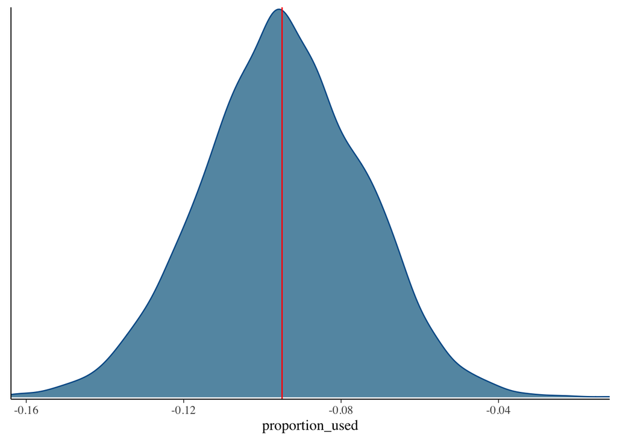

```r
line<-median(eb_data$proportion_used)
mcmc_dens(ethno_bayes_model, pars = c("proportion_used")) +
  vline_at(-0.095, col = "red")
```

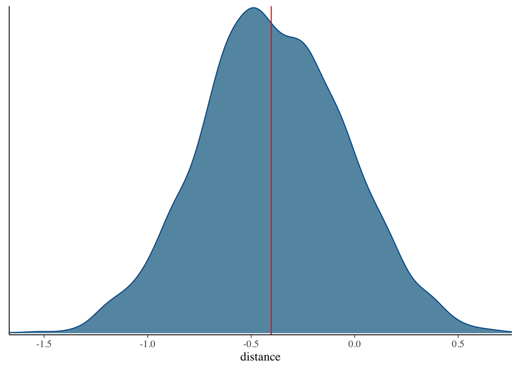

```r
mcmc_dens(ethno_bayes_model, pars=c("distance"))+
  vline_at(-0.403, col="red")
```

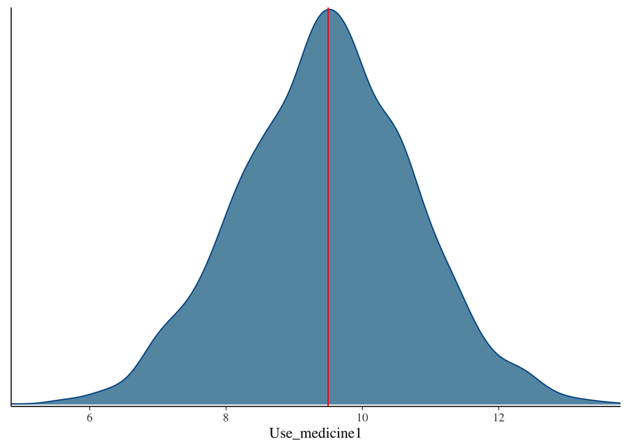

```r
mcmc_dens(ethno_bayes_model, pars=c("Use_medicine1")) +
  vline_at(9.497, col="red")
```

Now we evaluate the model parameters by analyzing the posteriors. We will look at the statistics shown in `describe_posterior` from `bayestestR` (Makowski et al. 2021).

```r
describe_posterior(posteriors = ethno_bayes_model)
```

```
## Summary of Posterior Distribution
##
## Parameter       | Median |         95% CI |     pd |          ROPE | % in ROPE |  Rhat |     ESS
## ------------------------------------------------------------------------------------------------
## (Intercept)     |  39.80 | [36.26, 43.40] |   100% | [-1.45, 1.45] |        0% | 1.000 | 4464.00
## proportion_used |  -0.10 | [-0.14, -0.06] |   100% | [-1.45, 1.45] |      100% | 1.000 | 5020.00
## distance        |  -0.40 | [-1.10,  0.28] | 86.50% | [-1.45, 1.45] |      100% | 1.000 | 5937.00
## Use_medicine1   |   9.50 | [ 6.92, 11.92] |   100% | [-1.45, 1.45] |        0% | 1.000 | 5437.00
```

The table shows (from left to right):

- The `Median` of the distribution (as above). The credible Interval `95% CI`, which can be used to quantify the uncertainty about the regression coefficients (the default highest density interval `ci_method = "hdi"` shows the probability (given the data) that a coefficient lies above the low value and under high value).
- The Probability of Direction `pd`, which is the probability that the effect goes to the positive or to the negative direction (a possible equivalent for the p-value).
- The Region of Practical Equivalence `ROPE` is a defined range around zero which can be considered practically the same as no effect (zero). It is similar to the probability of getting an effect equal to zero (the null hypothesis in linear regression) as a range rather than a point.
- The scale reduction factor `Rhat` computed for each scalar quantity of interest, as the standard deviation of that quantity from all the chains included together, divided by the root mean square of the separate within-chain standard deviations. When this value is close to 1 we do not have any convergence problem with MCMC.
- The effective sample size `ESS`, which captures how many independent draws contain the same amount of information as the dependent sample obtained by the MCMC algorithm, the higher the ESS the better. The threshold used in practice is 400.

Alternatively, we can get the coefficient estimates (which are the medians by default) separately by using the `get_parameters` function from the `insight` library (Lüdecke et al. 2021).

```r
posterior_samples <- get_parameters(ethno_bayes_model)
```

Use the `print` from base R and the `map_dbl` function from the `purrr` library (Henry and Wickham 2020) to show the results for the `posterior_samples` (the coefficients of the model).

```r
print(purrr::map_dbl(posterior_samples, median), digits = 3)
```

```
##     (Intercept) proportion_used        distance   Use_medicine1
##          39.798          -0.095          -0.403           9.497
```

As we see the values are closer to each other due to the like normality of the distribution of the posteriors where all the central statistics (mean, median, mode) are closer to each other. Using the following plot to visualize the proportion_used coefficient using different statistics as follows

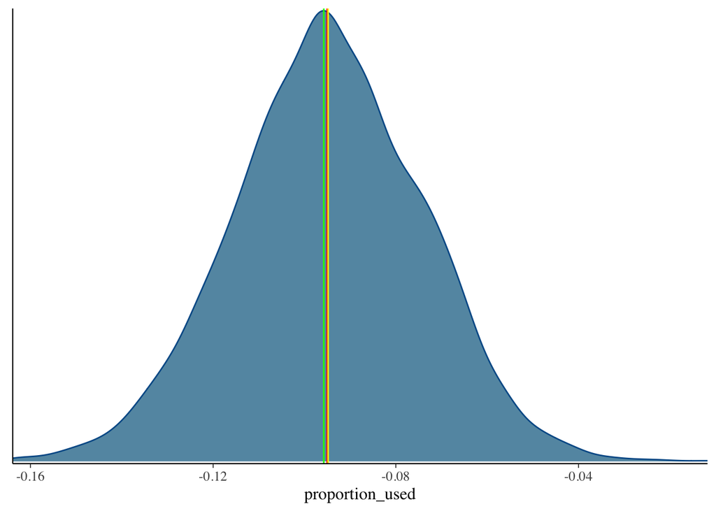

```r
mcmc_dens(ethno_bayes_model, pars = c("proportion_used"))+
  vline_at(median(posterior_samples$proportion_used), col = "red")+
  vline_at(mean(posterior_samples$proportion_used), col = "yellow")+
  vline_at(map_estimate(posterior_samples$proportion_used), col="green")
```

As expected they are approximately on top of each other.

# Bayesian inferences

`hdi`: As we an alternative to the significance testing in classical regression (frequentist), we can test if the corresponding credible interval contains zero or not, if no then this coefficient can be considered important. Let’s go back to our model and check the HDI of each coefficient.

```r
hdi(ethno_bayes_model)
```

```
## Highest Density Interval
##
## Parameter       |        95% HDI
## --------------------------------
## (Intercept)     | [36.26, 43.40]
## proportion_used | [-0.14, -0.06]
## distance        | [-1.10,  0.28]
## Use_medicine1   | [ 6.92, 11.92]
```

We can also check for the portion of the credible interval that falls inside the ROPE interval by calling the rope from `bayestestR` library.

```r
rope(posterior_samples$proportion_used)
```

```
## # Proportion of samples inside the ROPE [-0.10, 0.10]:
##
## inside ROPE
## -----------
## 60.72 %
```

Some of the credible interval of `proportion_used` variable is inside the ROPE interval. In other words, the probability of this coefficient to be zero is 60.72%.

```r
rope(posterior_samples$Use_medicine1)
```

```
## # Proportion of samples inside the ROPE [-0.10, 0.10]:
##
## inside ROPE
## -----------
## 0.00 %
```

For `Use_medicine1` all the credible interval (HDI) is outside the ROPE range, which corresponds to the linear regression finding that the coefficient is highly significant.

```r
 rope(posterior_samples$`(Intercept)`)
```

```
## # Proportion of samples inside the ROPE [-0.10, 0.10]:
##
## inside ROPE
## -----------
## 0.00 %
```

The same thing is true for the `intercept` variable.

```r
rope(posterior_samples$distance)
```

```
## # Proportion of samples inside the ROPE [-0.10, 0.10]:
##
## inside ROPE
## -----------
## 12.79 %
```

Some of the credible interval of distance variable is inside the ROPE interval. In other words, the probability of this coefficient to be zero is 12.79%.

```r
rope_range(ethno_bayes_model)
```

```
## [1] -1.449518  1.449518
```

# The Probability of Direction and p-value

Sometimes we are only interested in the direction of the coefficient (positive or negative). This is the role of the `pd` statistic in the above table. A high `pd` value means that the associated effect is concentrated on the same side as the median. This probability is closely related to the `p-value` (p-value = 1 − pd).

```r
df1 <-dplyr::select(tidy(model_freq), c(term, p.value))
df1$p.value <- round(df1$p.value, digits = 3)
df2 <- 1- purrr::map_dbl(posterior_samples, p_direction)
df <- cbind(df1, df2)
```

This document was generated with knitr (Xie 2021) and rmarkdown (Allaire et al. 2021).

# References

Allaire, JJ, Yihui Xie, Jonathan McPherson, Javier Luraschi, Kevin Ushey, Aron Atkins, Hadley Wickham, Joe Cheng, Winston Chang, and Richard Iannone. 2021. *Rmarkdown: Dynamic Documents for r*. https://CRAN.R-project.org/package=rmarkdown.

Gabry, Jonah, and Ben Goodrich. 2020. *Rstanarm: Bayesian Applied Regression Modeling via Stan*. https://CRAN.R-project.org/package=rstanarm.

Gabry, Jonah, and Tristan Mahr. 2021. *Bayesplot: Plotting for Bayesian Models*. https://mc-stan.org/bayesplot/.

Guo, Jiqiang, Jonah Gabry, Ben Goodrich, and Sebastian Weber. 2021. *Rstan: R Interface to Stan*.

Henry, Lionel, and Hadley Wickham. 2020. *Purrr: Functional Programming Tools*. https://CRAN.R-project.org/package=purrr.

Lüdecke, Daniel, Dominique Makowski, Indrajeet Patil, Philip Waggoner, Mattan S. Ben-Shachar, and Brenton M. Wiernik. 2021. *Insight: Easy Access to Model Information for Various Model Objects*. https://easystats.github.io/insight/.

Makowski, Dominique, Daniel Lüdecke, Mattan S. Ben-Shachar, Indrajeet Patil, and Michael D. Wilson. 2021. *bayestestR: Understand and Describe Bayesian Models and Posterior Distributions*. https://easystats.github.io/bayestestR/.

R Core Team. 2021. *R: A Language and Environment for Statistical Computing*. Vienna, Austria: R Foundation for Statistical Computing. https://www.R-project.org/.

Whitney, Cory. 2021. *ethnobotanyR: Calculate Quantitative Ethnobotany Indices*. https://CRAN.R-project.org/package=ethnobotanyR.

Xie, Yihui. 2021. *Knitr: A General-Purpose Package for Dynamic Report Generation in r*. https://yihui.org/knitr/.